# Sindemias e Covid-19 no Estado de São Paulo

Gustavo Casteletti de Alcântara

21/02/2022

## Trabalho Final do curso Relatório Reprodutiveis do Curso de Verão do IME da USP.

O presente trabalho é resultado do curso de [Relatórios Reprodutiveis](https://beatrizmilz.github.io/2022-curso-de-verao-ime-usp-relatorios/informacoes-gerais.html) do IME da USP sob a orientação da professora [Beatriz Milz](https://beatrizmilz.com/). A intenção é aplicar o conhecimento adquirido no Curso para a problemática da sindemia de Covid-19 nos municípios paulistas.

## O Conceito de Sindemia

O conceito de sindemia é tratado por [Singer e Clair, 2003](https://pubmed.ncbi.nlm.nih.gov/14716917/) como uma sinergia entre uma ou mais doenças. No exemplo citado, os autores analisaram como o entrelaçamento de uma ou mais doenças com contextos sociais e biopsicológicas produzem um novo paradigma à saúde pública de forma generalizada globalmente. Pelos dados oficiais, a Pandemia de Covid-19 no Brasil até a presente data levou à obito mais de 640 mil pessoas em todo o Brasil. Grande parte destes óbitos são de pessoas que apresentam comorbidades (uma ou mais doenças) que, associadas à infecção pelo virús Sars-cov-2, resultam em [grupos de risco da doença](https://www.seade.gov.br/covid-19-81-das-vitimas-da-regiao-do-vale-sofriam-de-comorbidades/). Assim, de forma exploratória e sem o devido tratamento estatistico, apresentarei como as comorbidades de diabetes e cardiopatia se relacionam nos óbitos de Covid-19 nos municípios do Estado de São Paulo. O banco de dados utilizado é de origem da Fundação Seade e disponível para reprodução e utilização.

## Metodologia - Preparando a minha base de dados

Para uma boa prática de Programação, é necessário limpar a base de dados do R. Portanto, aqui listo os comandos que realizo para deixar o ambiente mais clean possível. Vale ressaltar que a base de dados utilizada é de aproximadamente 800mb. Portanto, quanto menos arquivos estiver na minha RAM, melhor.

##Preparando meu ambiente de trabalho

### Limpando meu Ambiente de Trabalho

```r
rm( list = ls( ) )
graphics.off()
gc(reset = TRUE)
```

```
##          used (Mb) gc trigger (Mb) max used (Mb)
## Ncells 419829 22.5     877655 46.9   419829 22.5
## Vcells 761335  5.9    8388608 64.0   761335  5.9
```

```r
gc()
```

```
##          used (Mb) gc trigger (Mb) max used (Mb)
## Ncells 420280 22.5     877655 46.9   424662 22.7
## Vcells 762321  5.9    8388608 64.0   767918  5.9
```

A base de dados encontra-se em um link disponível para [download](https://raw.githubusercontent.com/seade-R/dados-covid-sp/master/data/casos_obitos_doencas_preexistentes.csv.zip). Porém, ela está disponível como um arquivo .zip, sendo necessária sua descompactação e também atribuição de seu caminho de destino.

Essa parte de Download e Descompactação poderia ser feita atráves de um serviço da Web. Como o arquivo é muito grande (aproximadamente 850mb), seria interessante ter uma máquina virtual para realizar o armazenamento e a descompactação do arquivo. Em breve, espero poder realizar tal atividade.

### Lendo a base de dados

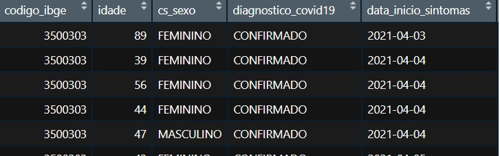

## Manipulação dos dados

Nessa etapa, há uma premissa importante que preciso ressaltar: acredito que tudo o que ocorre no espaço geográfico relaciona-se de forma mais ou menos intensa. [Tobler, p.237](https://www.jstor.org/stable/143141?refreqid=excelsior%3Ac529766f408f528030ea904a74d546e7) em 1970 indicava que “todas as coisas estão relacionadas, mas coisas próximas estão mais relacionadas do que coisas distantes”. Assim, compreender a interação das comorbidades e grupos de risco/óbitos no estado de São Paulo pode evidenciar ou não um padrão espacial de comorbidades em evidências. Diante disso, utilizei o pacote [Geobr](https://github.com/ipeaGIT/geobr) para fazer download do shapefile dos municípios de São Paulo e que futuramente, as variáveis e informações aqui geradas, poderão ser utilizadas em outras análises para sustentar a minha hipótese.

```r
dplyr::glimpse(mun_sp)
```

```
## Rows: 645
## Columns: 5
## $ code_muni    <dbl> 3500105, 3500204, 3500303, 3500402, 3500501, 3500550, 350~
## $ name_muni    <chr> "Adamantina", "Adolfo", "Aguaí", "Águas Da Prata", "Águas~
## $ code_state   <chr> "35", "35", "35", "35", "35", "35", "35", "35", "35", "35~
## $ abbrev_state <chr> "SP", "SP", "SP", "SP", "SP", "SP", "SP", "SP", "SP", "SP~
## $ geom         <MULTIPOLYGON [°]> MULTIPOLYGON (((-51.09093 -..., MULTIPOLYGON~
```

```r
sf::write_sf(mun_sp, dsn='mun_sp', driver='ESRI Shapefile')
```

###Exportação do Shapefile

### Alteração do nome de uma variável para realizar um Join

Aqui alterei o nome da variável que contém o código do município para realizar um [Join](https://dplyr.tidyverse.org/reference/mutate-joins.html) futuramente com a base de dados. É melhor que as duas variáveis tenham o mesmo nome e que suas id’s sejam iguais.

```r
mun_sp <- dplyr::rename(mun_sp, codigo_ibge = 'code_muni')

names (mun_sp)
```

```
## [1] "codigo_ibge"  "name_muni"    "code_state"   "abbrev_state" "geom"
```

### Relação das Variáveis

O Intuito deste tópico é analisar, atráves do banco de dados, como as doenças de Diabetes e Cardiopatia se relacionam. Assim, a partir de uma breve [limpeza dos dados](https://github.com/gustavoalcantara/sindemia/blob/master/limpeza_dados.R), foi possível juntar as duas doenças e analisar a idade média dos óbitos para cada municipio de São Paulo. Portanto, da tabela de pouco mais de 4 milhões de registros individuais, consegui fazer o join das duas tabelas que necessito.

```
## Rows: 632
## Columns: 4
## $ X                    <int> 1, 2, 3, 4, 5, 6, 7, 8, 9, 10, 11, 12, 13, 14, 15~
## $ codigo_ibge          <int> 3500105, 3500204, 3500303, 3500402, 3500501, 3500~
## $ idade_media          <dbl> 73.79630, 65.71429, 67.28302, 73.64706, 66.43333,~
## $ idade_media_diabetes <dbl> 65.58333, 69.71429, 65.94595, 71.90909, 68.50000,~
```

## Gráficos e interações

Em um primeiro cenário de análise, é válido verificar a dispersão da idade média dessas comorbidades nos municípios paulistas. Essa atividade pode gerar insights sobre o agrupamento das idades médias e suas dispersões (“outliers”). Será que municípios que possuem idades médias mais avançadas possuem uma população mais idosa? Assim, elaborei um gráfico simples de dispersão para verificar como é essa distribuição.

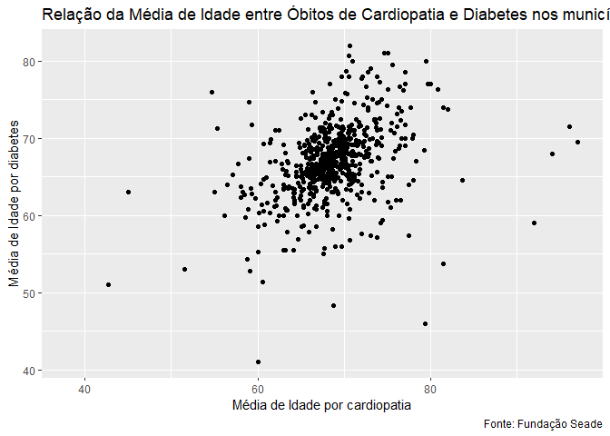

```r
library(ggplot2)
ggplot2::ggplot(dados, aes(x=idade_media,
                     y=idade_media_diabetes))+
  geom_point()+
  labs(title = "Relação da Média de Idade entre Óbitos de Cardiopatia e Diabetes nos municípios paulistas",
              x="Média de Idade por cardiopatia",
              y="Média de Idade por diabetes",
              caption='Fonte: Fundação Seade')
```

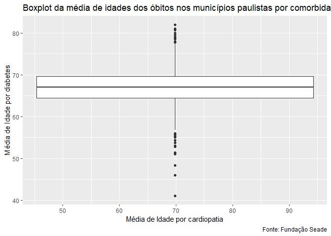

```r
ggplot2::ggplot(dados,
                mapping = aes(x=idade_media,
                              y=idade_media_diabetes))+
  geom_boxplot()+
   labs(title = "Boxplot da média de idades dos óbitos nos municípios paulistas por comorbidades",
              x="Média de Idade por cardiopatia",
              y="Média de Idade por diabetes",
              caption='Fonte: Fundação Seade')
```

###Join das variáveis